# Palmer Penguins: Statistical Modelling & Visualisation

Adam Robinson

# Introduction

This report explores the Palmer Penguins dataset to answer three questions:

1. How do penguin species differ in physical measurements?
2. Are these differences statistically significant?
3. Can we predict species based on their physical characteristics?

We’ll use summary statistics, plots, ANOVA and t-tests for comparisons, and a decision tree classifier for predictions.

# Data Review & Cleaning

We will start by loading the penguins dataset and exploring the data. We will check the structure, identify missing values, and prepare a clean dataset for plots, tests, and models.

```r
# Load the data
data("penguins")   # Load penguins dataset

# First look at the dataset
head(penguins)
```

```
## # A tibble: 6 × 8
##   species island    bill_length_mm bill_depth_mm flipper_length_mm body_mass_g
##   <fct>   <fct>              <dbl>         <dbl>             <int>       <int>
## 1 Adelie  Torgersen           39.1          18.7               181        3750
## 2 Adelie  Torgersen           39.5          17.4               186        3800
## 3 Adelie  Torgersen           40.3          18                 195        3250
## 4 Adelie  Torgersen           NA            NA                  NA          NA
## 5 Adelie  Torgersen           36.7          19.3               193        3450
## 6 Adelie  Torgersen           39.3          20.6               190        3650
## # ℹ 2 more variables: sex <fct>, year <int>
```

```r
# Check missing values
cat("No. of missing values: ",sum(is.na(penguins)), "\n")
```

```
## No. of missing values:  19
```

```r
# Remove rows with missing values
penguins_clean <- na.omit(penguins)

# Number of rows and columns
cat("No. of rows: ", nrow(penguins_clean), "\n")
```

```
## No. of rows:  333
```

```r
cat("No. of columns: ", ncol(penguins_clean), "\n")
```

```
## No. of columns:  8
```

```r
# Unique values
cat("\nSpecies: \n");unique(penguins_clean$species)
```

```
##
## Species:
```

```
## [1] Adelie    Gentoo    Chinstrap
## Levels: Adelie Chinstrap Gentoo
```

```r
cat("\nIslands: \n");unique(penguins_clean$island)
```

```
##
## Islands:
```

```
## [1] Torgersen Biscoe    Dream
## Levels: Biscoe Dream Torgersen
```

```r
# Dataset summary
summary(penguins)
```

```
##       species          island    bill_length_mm  bill_depth_mm
##  Adelie   :152   Biscoe   :168   Min.   :32.10   Min.   :13.10
##  Chinstrap: 68   Dream    :124   1st Qu.:39.23   1st Qu.:15.60
##  Gentoo   :124   Torgersen: 52   Median :44.45   Median :17.30
##                                  Mean   :43.92   Mean   :17.15
##                                  3rd Qu.:48.50   3rd Qu.:18.70
##                                  Max.   :59.60   Max.   :21.50
##                                  NA's   :2       NA's   :2
##  flipper_length_mm  body_mass_g       sex           year
##  Min.   :172.0     Min.   :2700   female:165   Min.   :2007
##  1st Qu.:190.0     1st Qu.:3550   male  :168   1st Qu.:2007
##  Median :197.0     Median :4050   NA's  : 11   Median :2008
##  Mean   :200.9     Mean   :4202                Mean   :2008
##  3rd Qu.:213.0     3rd Qu.:4750                3rd Qu.:2009
##  Max.   :231.0     Max.   :6300                Max.   :2009
##  NA's   :2         NA's   :2
```

# Exploratory Data Analysis

We will now take a closer look at distributions of each variable and the relationships between penguin species.

### Summary Statistics by Species

```r
# Summary statistics by species
cat("Average Bill Length\n");tapply(penguins_clean$bill_length_mm, penguins_clean$species, mean)
```

```
## Average Bill Length
```

```
##    Adelie Chinstrap    Gentoo
##  38.82397  48.83382  47.56807
```

```r
cat("\nAverage Bill Depth\n");tapply(penguins_clean$bill_depth_mm, penguins_clean$species, mean)
```

```
##
## Average Bill Depth
```

```
##    Adelie Chinstrap    Gentoo
##  18.34726  18.42059  14.99664
```

```r
cat("\nAverage Flipper Length\n");tapply(penguins_clean$flipper_length_mm, penguins_clean$species, mean)
```

```
##
## Average Flipper Length
```

```
##    Adelie Chinstrap    Gentoo
##  190.1027  195.8235  217.2353
```

```r
cat("\nAverage Body Mass\n");tapply(penguins_clean$body_mass_g, penguins_clean$species, mean)
```

```
##
## Average Body Mass
```

```
##    Adelie Chinstrap    Gentoo
##  3706.164  3733.088  5092.437
```

```r
cat("\nNo. of Each Species");table(penguins_clean$species)
```

```
##
## No. of Each Species
```

```
##
##    Adelie Chinstrap    Gentoo
##       146        68       119
```

### Distribution of Species by Island

```r
# Island distribution table
table(penguins_clean$island, penguins_clean$species)
```

```
##
##             Adelie Chinstrap Gentoo
##   Biscoe        44         0    119
##   Dream         55        68      0
##   Torgersen     47         0      0
```

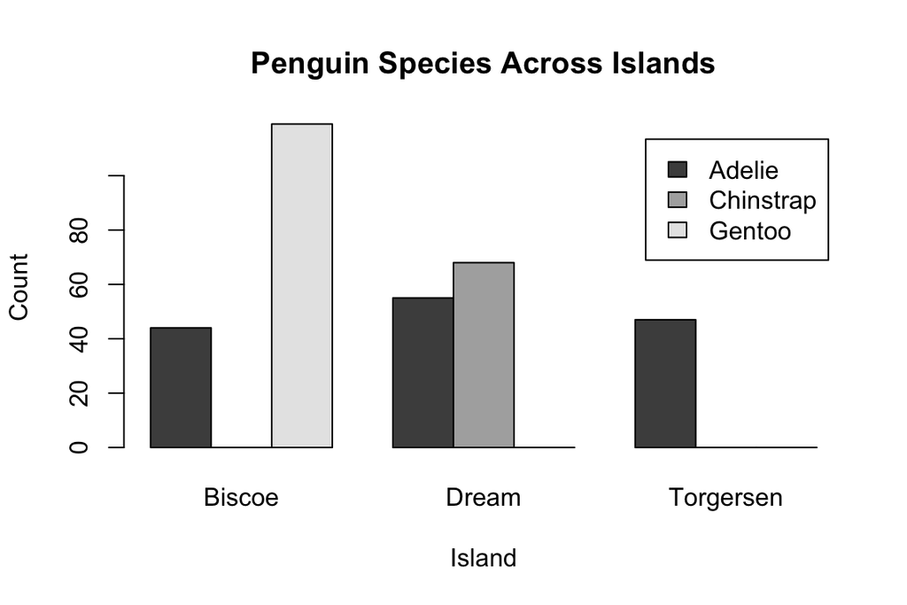

```r
# Island distribution bar chart
barplot(table(penguins_clean$species, penguins_clean$island),
        beside = TRUE, legend = TRUE,
        main = "Penguin Species Across Islands",
        xlab = "Island", ylab = "Count")
```

Adelie penguins are found in all 3 islands, whereas Chinstrap and Gentoo penguins are exclusive to Dream and Biscoe respectively.

### Flipper Length Across Species

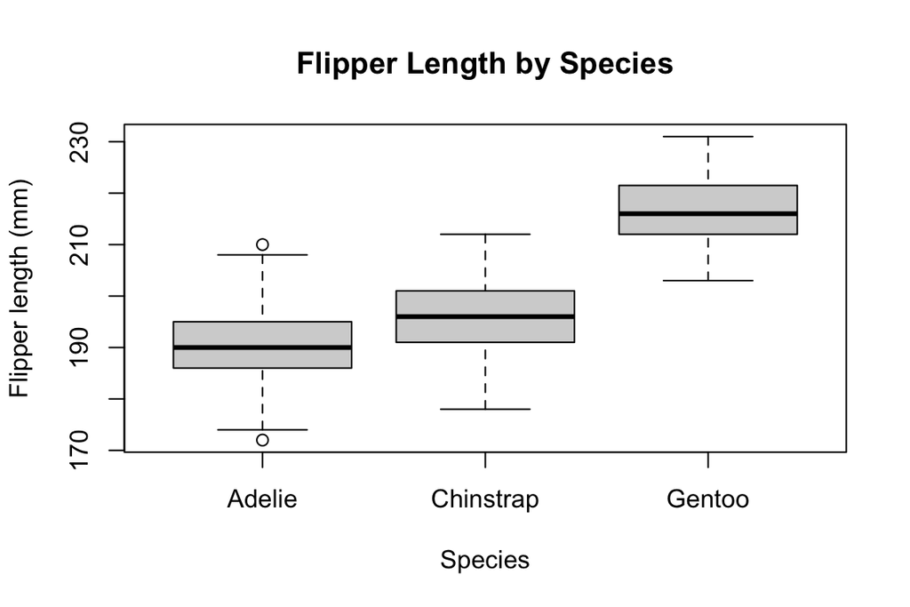

```r
# Flipper length box plot
boxplot(flipper_length_mm ~ species, data = penguins_clean,
        main = "Flipper Length by Species",
        xlab = "Species", ylab = "Flipper length (mm)")
```

Gentoo penguins typically have the longest flippers, while Adelie penguins tend to have the shortest flippers, with Adelie and Chinstrap penguins having similar flipper lengths.

### Body Mass Across Species

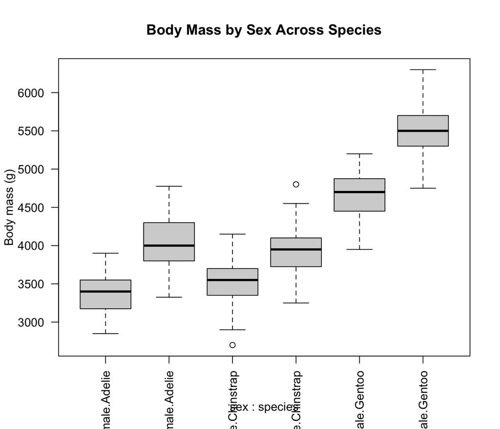

```r
# Body mass box plot
boxplot(body_mass_g ~ sex + species, data = penguins_clean,
        main = "Body Mass by Sex Across Species",
        ylab = "Body mass (g)", las = 2)
```

Male penguins are heavier than female penguins in all species on average. Both male and female Gentoo penguins are heavier than both other penguin species - these two species follow broadly similar weight measurements.

### Body Mass vs. Flipper Length

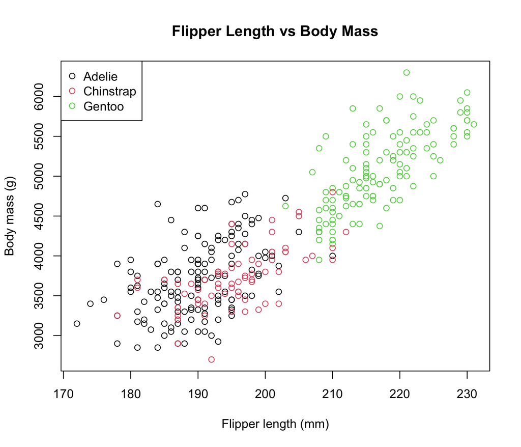

```r
# Body Mass vs. Flipper Length scatter plot
plot(penguins_clean$flipper_length_mm, penguins_clean$body_mass_g,
     col = penguins_clean$species,
     xlab = "Flipper length (mm)", ylab = "Body mass (g)",
     main = "Flipper Length vs Body Mass")
legend("topleft", legend = levels(penguins_clean$species), col = 1:3, pch = 1)
```

There is a positive correlation between flipper length and body mass. It also appears that Gentoo penguins are generally heavier and have longer flippers than both Adelie and Chinstrap penguins.

### Bill Length Across Species

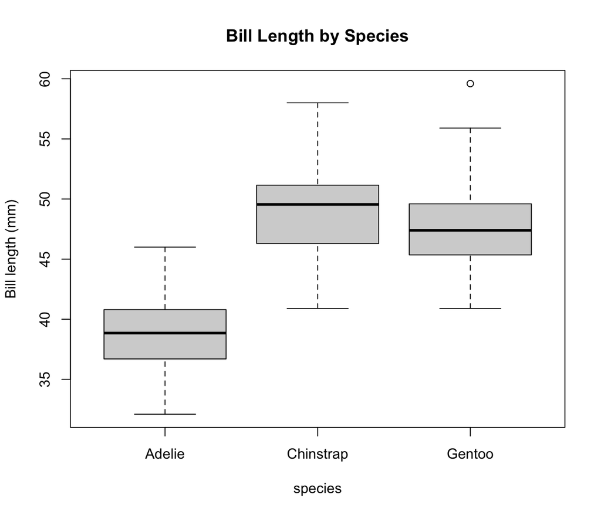

```r
# Bill lengths box plot
boxplot(bill_length_mm ~ species, data = penguins_clean,
        main = "Bill Length by Species",
        ylab = "Bill length (mm)")
```

Adelie penguins have much shorter bills than both Chinstrap and Gentoo penguins, both of which have fairly similar bill lengths overall.

# Statistical Testing

We will now test whether bill lengths and body mass differ significantly across species using an Analysis of Variance test.

```r
# ANOVA: Bill lengths
anova_bill_length <- aov(bill_length_mm ~ species, data = penguins_clean)
summary(anova_bill_length)
```

```
##              Df Sum Sq Mean Sq F value Pr(>F)
## species       2   7015    3508   397.3 <2e-16 ***
## Residuals   330   2914       9
## ---
## Signif. codes:  0 '***' 0.001 '**' 0.01 '*' 0.05 '.' 0.1 ' ' 1
```

```r
# ANOVA: Body mass
anova_mass <- aov(body_mass_g ~ species, data = penguins_clean)
summary(anova_mass)
```

```
##              Df    Sum Sq  Mean Sq F value Pr(>F)
## species       2 145190219 72595110   341.9 <2e-16 ***
## Residuals   330  70069447   212332
## ---
## Signif. codes:  0 '***' 0.001 '**' 0.01 '*' 0.05 '.' 0.1 ' ' 1
```

Bill length differs strongly across species. The ANOVA shows F = 397.3, p < 0.001.  
Body mass also differs across species. The ANOVA shows F = 341.9, p < 0.001.  
In both cases, the F value is large, meaning that the differences between species are much bigger than the differences within species. The P value is also very small meaning that the results are statistically significant and highly unlikely due to chance. Thus, we conclude that species is a strong factor in both bill length and body mass.

We will now test the flipper lengths of the penguins species using a two sample t-test.

```r
# Adelie vs Chinstrap
adelie_chinstrap <- subset(penguins_clean, species %in% c("Adelie","Chinstrap"))
t.test(flipper_length_mm ~ species, data = adelie_chinstrap)
```

```
##
##  Welch Two Sample t-test
##
## data:  flipper_length_mm by species
## t = -5.6115, df = 120.88, p-value = 1.297e-07
## alternative hypothesis: true difference in means between group Adelie and group Chinstrap is not equal to 0
## 95 percent confidence interval:
##  -7.739129 -3.702450
## sample estimates:
##    mean in group Adelie mean in group Chinstrap
##                190.1027                195.8235
```

```r
# Adelie vs Gentoo
adelie_gentoo <- subset(penguins_clean, species %in% c("Adelie","Gentoo"))
t.test(flipper_length_mm ~ species, data = adelie_gentoo)
```

```
##
##  Welch Two Sample t-test
##
## data:  flipper_length_mm by species
## t = -33.506, df = 251.35, p-value < 2.2e-16
## alternative hypothesis: true difference in means between group Adelie and group Gentoo is not equal to 0
## 95 percent confidence interval:
##  -28.72740 -25.53771
## sample estimates:
## mean in group Adelie mean in group Gentoo
##             190.1027             217.2353
```

Chinstrap flippers are about 6 mm longer than Adelie on average - a small but significant gap, with p < 0.001.

Gentoo flippers are about 27 mm longer than Adelie - a much larger, and also significant, difference, again with p < 0.001.

# Predictive modelling

We now train a decision tree classification model using 70% of the data to predict species from a penguin’s body measurements, testing the model on the remaining 30% of the data.

```r
set.seed(123)

# Split data: train (70%) and test (30%)
n <- nrow(penguins_clean)
index <- sample(1:n, size = 0.7*n)
train <- penguins_clean[index, ]
test  <- penguins_clean[-index, ]

# Fit decision tree on training data
model <- rpart(species ~ bill_length_mm + bill_depth_mm + flipper_length_mm + body_mass_g,
               data = train, method = "class")

# Predict on test set
predictions <- predict(model, newdata = test, type = "class")
```

### Model Performance

```r
# Confusion matrix
confusion_matrix <- table(Predicted = predictions, Actual = test$species)
confusion_matrix
```

```
##            Actual
## Predicted   Adelie Chinstrap Gentoo
##   Adelie        40         1      0
##   Chinstrap      3        23      0
##   Gentoo         0         0     33
```

```r
accuracy <- sum(diag(confusion_matrix)) / sum(confusion_matrix)
cat("Overall accuracy:", round(accuracy * 100, 1), "%\n")
```

```
## Overall accuracy: 96 %
```

```r
# Sensitivity and Specificity for each species
species <- c("Adelie", "Chinstrap", "Gentoo")

for (s in species) {
  TP <- confusion_matrix[s, s]
  FN <- sum(confusion_matrix[, s]) - TP
  FP <- sum(confusion_matrix[s, ]) - TP
  TN <- sum(confusion_matrix) - TP - FN - FP

  sensitivity <- TP / (TP + FN)
  specificity <- TN / (TN + FP)

  cat("\nSpecies:", s, "\n")
  cat("Sensitivity:", round(sensitivity * 100, 1), "%\n")
  cat("Specificity:", round(specificity * 100, 1), "%\n")
}
```

```
##
## Species: Adelie
## Sensitivity: 93 %
## Specificity: 98.2 %
##
## Species: Chinstrap
## Sensitivity: 95.8 %
## Specificity: 96.1 %
##
## Species: Gentoo
## Sensitivity: 100 %
## Specificity: 100 %
```

# Model visualisation

### Predicted vs. Actual Species

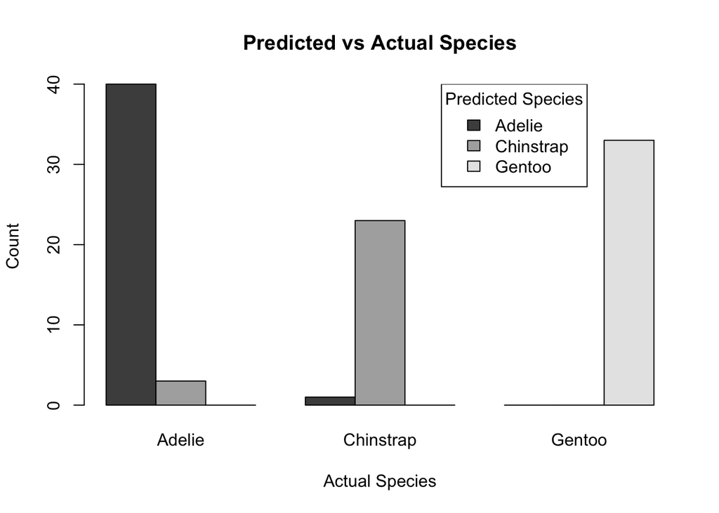

```r
# Predicted vs Actual Species Plot
barplot(confusion_matrix, beside = TRUE,
        main = "Predicted vs Actual Species",
        xlab = "Actual Species", ylab = "Count")

# Add legend with title
legend("topright", legend = colnames(confusion_matrix), fill = gray.colors(ncol(confusion_matrix)),
       title = "Predicted Species", inset = c(0.15, 0))
```

This chart shows visual evidence of the previous findings, that the majority of the penguins’ species are correctly classified.

### Decision Tree visualisation

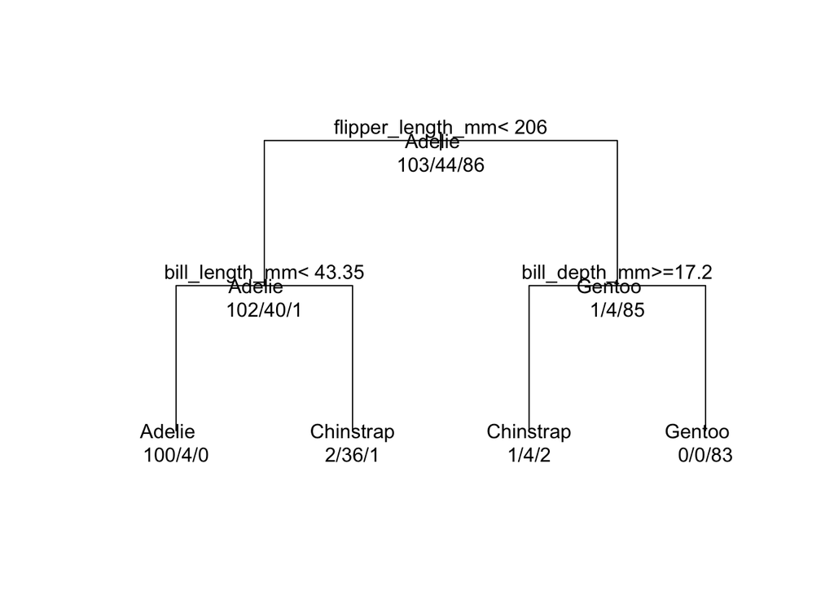

```r
# Visualize Decision Tree
plot(model, uniform = TRUE, margin = 0.1)
text(model, use.n = TRUE, all = TRUE)
```

# Conclusion

The results show that physical traits alone are a strong basis to predict species. For even greater accuracy, future models may use non-physical data, such as island inhabited, since initial exploration showed strong species separation by island. Additionally, exploring different models, like random forest or logistic regression, could also improve classification accuracy.